## Milestone Report for Data Science Capstone Project

This report is the part of the natural language processing project which is aimed at understanding and building predictive text models.

### Data source

The data is from HC Corpora. It consists of news, blog and twitter data for different locales. We choose English locale for our project. More detailes about data you can find in readme file at corpora website: [ReadMe](http://www.corpora.heliohost.org/aboutcorpus.html).

### Data

The data that we used for feather analysis consists of three files with mostly English text from news, blogs, and twitter. Here are basic summaries like counts of lines and words and size for these three files:

```
##                   line_counts word_counts sizeMb
## en_US.blogs.txt        899288    37334131  200.4
## en_US.news.txt        1010242    34372530  196.3
## en_US.twitter.txt     2360148    30373583  159.4
```

### Data Processing

Before exploratory data analysis data was cleaned and were prepered tidy corpus for each source file. During cleaning all data was transformed to lower case. All special characters, except important punctuation marks and some other meaningful characters (“.”, “,”, “!”, “?”, “-”, “apostrophe”), were removed, as well as smiles. “;” character was replacesed with “,”, and “.”, “,”, “!”, “?” punctuation marks were treated as words during building process of predictive text model. We choose this approach because it allows to predict punctuation as well and also to save meaningful text separation. Also we desided not to remove stop words. All digits, e-mails, and profanity words were replaced with tags “digit”, “e-mail”, and “badword” respectively. For profanity filtering the small dictionary of bad words was used [bad-words-list](http://urbanoalvarez.es/blog/2008/04/04/bad-words-list/). For hashtags only “#” symbol was removed because usually they are meaningful. After this all procedures white space correction was perfomed in order to remove all duplicates of space characters.

### Creation of n-gram counts

After cleaning data was tokenized and 1, 2, 3 and 4 grams were created. We created n-grams for each file separately, because for instance twitter data differ significantly from other sources. N-grams contain a lot of words that have very low count, most of them happens only once in source file. This fact was used futher for removing misspelled words, words from another language and for optimization of model. All n-grams that had count 1 was removed from n-gram sets. Also we found that the percent of most frequent words that cover most n-gram counts differ for different n (here are presented percentage results for subset of original data):

- roughtly 0.6% 1-grams contain 50% of counts and 30% 1-grams contain 90% of counts
- roughtly 16% 2-grams contain 50% of counts and 83% 2-grams contain 90% of counts
- roughtly 45% 3-grams contain 50% of counts and 89% contain 90% of counts

Which is expected because there are more different combinations of words in n-grams when n is big, and even with a large amount of data some n-grams will be very rare in text.

We analysed frequencies of the different words in data. Here is barplot of some most frequent words for one of the source files, namely twitter data:

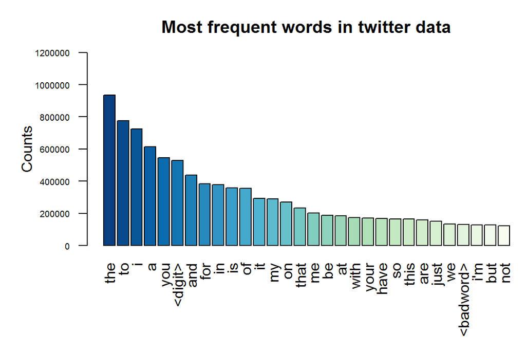

As we can see there are a lot of stopwords here as was expected. Also we can see a lot of badwords which is the specific feature of twitter data. This kind of words more rare in data from another sources like news. Also there are a lot of digits there.

Here is most frequent n-grams for twitter data. As we can see, when n-grows the counts become distributed more uniformly with much lower maximal counts for most frequent n-grams.

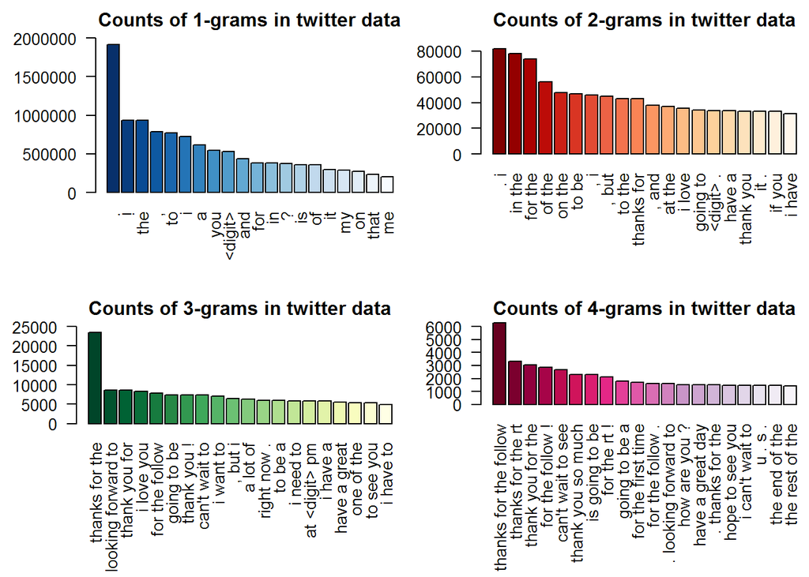

Similar analysis were performed for news and blogs data.